# Beer Study

## Median Alcohol By Volume (ABV) by State

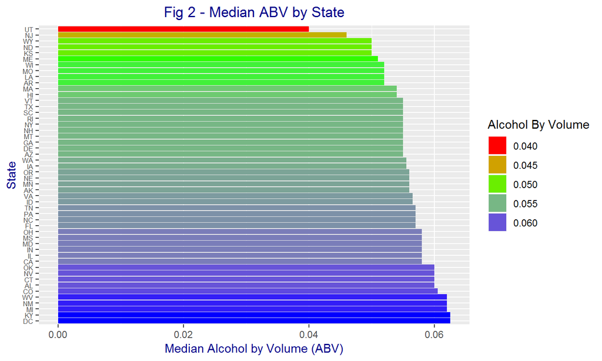

## Median International Bitterness Unit (IBU) by State

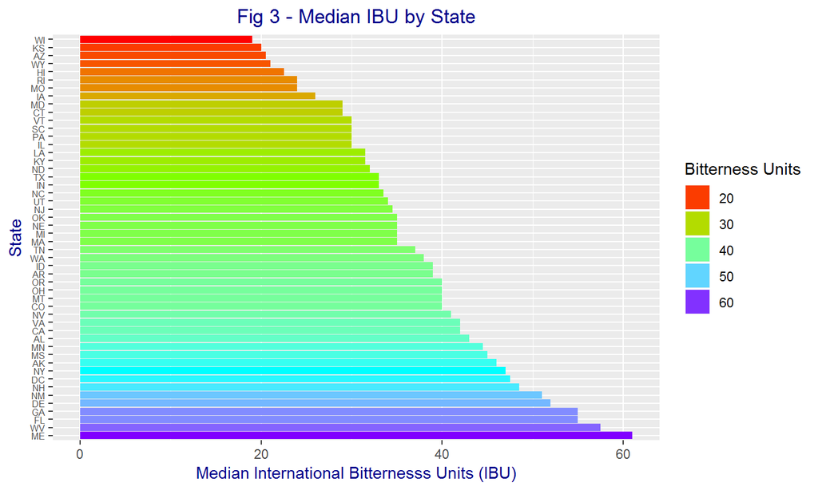

## State with Highest ABV

Table 5 - State with the Most Alcohol by Volume (ABV)

| BreweryID | BreweryName | City | State | BeerName | BeerID | AlcoholByVolume | BitternessUnits | BeerStyle | Ounces |
| --- | --- | --- | --- | --- | --- | --- | --- | --- | --- |
| 52 | Upslope Brewing Company | Boulder | CO | Lee Hill Series Vol. 5 - Belgian Style Quadrupel Ale | 2565 | 0.128 | NA | Quadrupel (Quad) | 19.2 |

The state with the maximum alcoholic beer is Colorado. It has a 0.128 ABV and comes from the Upslope Brewing Company. The beer is the Lee Hill Series Vol. 5, a Belgian Style Quadrupel Ale.

## State with Highest IBU Beer

Table 6 - State with the Highest International Bitterness Units (IBU)

| BreweryID | BreweryName | City | State | BeerName | BeerID | AlcoholByVolume | BitternessUnits | BeerStyle | Ounces |
| --- | --- | --- | --- | --- | --- | --- | --- | --- | --- |
| 375 | Astoria Brewing Company | Astoria | OR | Bitter Bitch Imperial IPA | 980 | 0.082 | 138 | American Double / Imperial IPA | 12 |

The state with the highest bitterness beer score is Oregon. It has a 138 IBUs and comes from the Astoria Brewing Company. The beer is the Bitter Bitch Imperial IPA, an American Double/Imperial IPA.

## ABV Summary

Table 7 - Summary Statistics for Alcohol By Volume (ABV)

| Min. | 1st Qu. | Median | Mean | 3rd Qu. | Max. | NA's |
| --- | --- | --- | --- | --- | --- | --- |
| 0.001 | 0.05 | 0.056 | 0.0597734 | 0.067 | 0.128 | 62 |

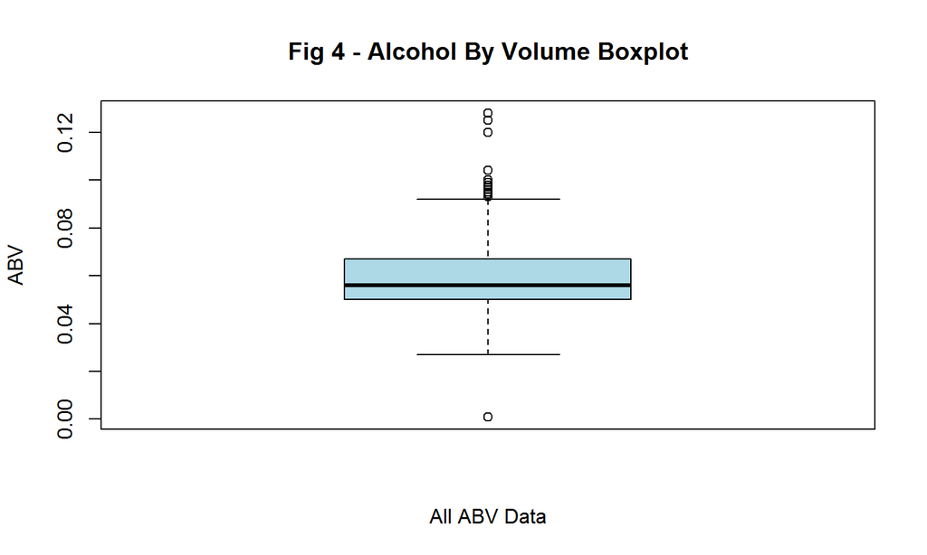

## ABV vs IBU

[figure not shown]

r = 0.671, positive linear correlation \[r^{2} = 0.4502\]

## BACKUP

```r
cor.test(allBeerDataDF$AlcoholByVolume, allBeerDataDF$BitternessUnits)
```

```
##
##  Pearson's product-moment correlation
##
## data:  allBeerDataDF$AlcoholByVolume and allBeerDataDF$BitternessUnits
## t = 33.863, df = 1403, p-value < 2.2e-16
## alternative hypothesis: true correlation is not equal to 0
## 95 percent confidence interval:
##  0.6407982 0.6984238
## sample estimates:
##       cor
## 0.6706215
```